# Risk Factor Analysis

## Outcome Variable

**Outcome Variable:** y_rate_haz

## Predictor Variables

**Intervention Variable:** fhtcm

**Adjustment Set:**

- arm
- W_mage
- W_fage
- meducyrs
- feducyrs
- W_mhtcm
- W_mwtkg
- W_mbmi
- single
- delta_W_fage
- delta_meducyrs
- delta_feducyrs
- delta_W_mhtcm
- delta_W_mwtkg
- delta_W_mbmi
- delta_single

## Stratifying Variables

The analysis was stratified on these variable(s):

- agecat
- studyid
- country

## Data Summary

| agecat | studyid | country | fhtcm | n_cell | n |
| --- | --- | --- | --- | --- | --- |
| 0-3 months | ki1119695-PROBIT | BELARUS | [160-170) | 1277 | 11500 |
| 0-3 months | ki1119695-PROBIT | BELARUS | <160 | 52 | 11500 |
| 0-3 months | ki1119695-PROBIT | BELARUS | >=170 | 10171 | 11500 |
| 0-3 months | ki1101329-Keneba | GAMBIA | [160-170) | 529 | 965 |
| 0-3 months | ki1101329-Keneba | GAMBIA | <160 | 23 | 965 |
| 0-3 months | ki1101329-Keneba | GAMBIA | >=170 | 413 | 965 |
| 0-3 months | ki1135781-COHORTS | GUATEMALA | [160-170) | 88 | 180 |
| 0-3 months | ki1135781-COHORTS | GUATEMALA | <160 | 80 | 180 |
| 0-3 months | ki1135781-COHORTS | GUATEMALA | >=170 | 12 | 180 |
| 0-3 months | ki1000304b-SAS-CompFeed | INDIA | [160-170) | 412 | 716 |
| 0-3 months | ki1000304b-SAS-CompFeed | INDIA | <160 | 109 | 716 |
| 0-3 months | ki1000304b-SAS-CompFeed | INDIA | >=170 | 195 | 716 |
| 3-6 months | ki1119695-PROBIT | BELARUS | [160-170) | 1117 | 10104 |
| 3-6 months | ki1119695-PROBIT | BELARUS | <160 | 45 | 10104 |
| 3-6 months | ki1119695-PROBIT | BELARUS | >=170 | 8942 | 10104 |
| 3-6 months | ki1101329-Keneba | GAMBIA | [160-170) | 569 | 1037 |
| 3-6 months | ki1101329-Keneba | GAMBIA | <160 | 24 | 1037 |
| 3-6 months | ki1101329-Keneba | GAMBIA | >=170 | 444 | 1037 |
| 3-6 months | ki1135781-COHORTS | GUATEMALA | [160-170) | 131 | 261 |
| 3-6 months | ki1135781-COHORTS | GUATEMALA | <160 | 111 | 261 |
| 3-6 months | ki1135781-COHORTS | GUATEMALA | >=170 | 19 | 261 |
| 3-6 months | ki1000304b-SAS-CompFeed | INDIA | [160-170) | 389 | 682 |
| 3-6 months | ki1000304b-SAS-CompFeed | INDIA | <160 | 102 | 682 |
| 3-6 months | ki1000304b-SAS-CompFeed | INDIA | >=170 | 191 | 682 |
| 6-12 months | ki1119695-PROBIT | BELARUS | [160-170) | 1089 | 9870 |
| 6-12 months | ki1119695-PROBIT | BELARUS | <160 | 42 | 9870 |
| 6-12 months | ki1119695-PROBIT | BELARUS | >=170 | 8739 | 9870 |
| 6-12 months | ki1101329-Keneba | GAMBIA | [160-170) | 555 | 1005 |
| 6-12 months | ki1101329-Keneba | GAMBIA | <160 | 25 | 1005 |
| 6-12 months | ki1101329-Keneba | GAMBIA | >=170 | 425 | 1005 |
| 6-12 months | ki1135781-COHORTS | GUATEMALA | [160-170) | 164 | 329 |
| 6-12 months | ki1135781-COHORTS | GUATEMALA | <160 | 142 | 329 |
| 6-12 months | ki1135781-COHORTS | GUATEMALA | >=170 | 23 | 329 |
| 6-12 months | ki1000304b-SAS-CompFeed | INDIA | [160-170) | 387 | 679 |
| 6-12 months | ki1000304b-SAS-CompFeed | INDIA | <160 | 94 | 679 |
| 6-12 months | ki1000304b-SAS-CompFeed | INDIA | >=170 | 198 | 679 |
| 6-12 months | ki1000304b-SAS-FoodSuppl | INDIA | [160-170) | 199 | 328 |
| 6-12 months | ki1000304b-SAS-FoodSuppl | INDIA | <160 | 85 | 328 |
| 6-12 months | ki1000304b-SAS-FoodSuppl | INDIA | >=170 | 44 | 328 |
| 12-24 months | ki1119695-PROBIT | BELARUS | [160-170) | 253 | 2320 |
| 12-24 months | ki1119695-PROBIT | BELARUS | <160 | 15 | 2320 |
| 12-24 months | ki1119695-PROBIT | BELARUS | >=170 | 2052 | 2320 |
| 12-24 months | ki1101329-Keneba | GAMBIA | [160-170) | 527 | 931 |
| 12-24 months | ki1101329-Keneba | GAMBIA | <160 | 21 | 931 |
| 12-24 months | ki1101329-Keneba | GAMBIA | >=170 | 383 | 931 |
| 12-24 months | ki1135781-COHORTS | GUATEMALA | [160-170) | 206 | 421 |
| 12-24 months | ki1135781-COHORTS | GUATEMALA | <160 | 183 | 421 |
| 12-24 months | ki1135781-COHORTS | GUATEMALA | >=170 | 32 | 421 |

The following strata were considered:

- agecat: 0-3 months, studyid: ki1000304b-SAS-CompFeed, country: INDIA
- agecat: 0-3 months, studyid: ki1101329-Keneba, country: GAMBIA
- agecat: 0-3 months, studyid: ki1119695-PROBIT, country: BELARUS
- agecat: 0-3 months, studyid: ki1135781-COHORTS, country: GUATEMALA
- agecat: 12-24 months, studyid: ki1101329-Keneba, country: GAMBIA
- agecat: 12-24 months, studyid: ki1119695-PROBIT, country: BELARUS
- agecat: 12-24 months, studyid: ki1135781-COHORTS, country: GUATEMALA
- agecat: 3-6 months, studyid: ki1000304b-SAS-CompFeed, country: INDIA
- agecat: 3-6 months, studyid: ki1101329-Keneba, country: GAMBIA
- agecat: 3-6 months, studyid: ki1119695-PROBIT, country: BELARUS
- agecat: 3-6 months, studyid: ki1135781-COHORTS, country: GUATEMALA
- agecat: 6-12 months, studyid: ki1000304b-SAS-CompFeed, country: INDIA
- agecat: 6-12 months, studyid: ki1000304b-SAS-FoodSuppl, country: INDIA
- agecat: 6-12 months, studyid: ki1101329-Keneba, country: GAMBIA
- agecat: 6-12 months, studyid: ki1119695-PROBIT, country: BELARUS
- agecat: 6-12 months, studyid: ki1135781-COHORTS, country: GUATEMALA

## Methods Detail

We’re interested in the causal parameters $E[Y_a]$ for all values of $a \in \mathcal{A}$. These parameters represent the mean outcome if, possibly contrary to fact, we intervened to set all units to have $A=a$. Under the randomization and positivity assumptions, these are identified by the statistical parameters $\psi_a=E_W[E_{Y|A,W}(Y|A=a,W)]$. In addition, we’re interested in the mean of $Y$, $E[Y]$ under no intervention (the observed mean). We will estimate these parameters by using SuperLearner to fit the relevant likelihood factors – $E_{Y|A,W}(Y|A=a,W)$ and $p(A=a|W)$, and then updating our likelihood fit using a joint TMLE.

For unadjusted analyses ($W=\{\}$), initial likelihoods were estimated using Lrnr_glm to estimate the simple $E(Y|A)$ and Lrnr_mean to estimate $p(A)$. For adjusted analyses, a small library containing Lrnr_glmnet, Lrnr_xgboost, and Lrnr_mean was used.

# Results Detail

## Results Plots

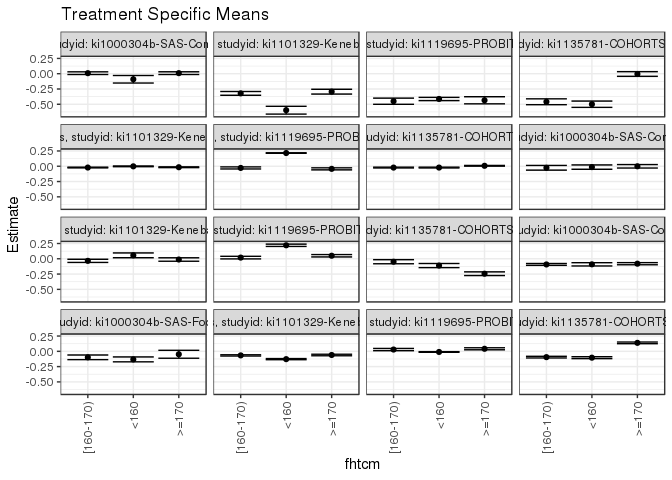

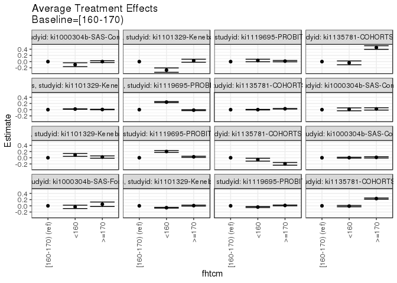

## Results Table

### Parameter: TSM

| agecat | studyid | country | intervention_level | baseline_level | estimate | ci_lower | ci_upper |
| --- | --- | --- | --- | --- | --- | --- | --- |
| 0-3 months | ki1000304b-SAS-CompFeed | INDIA | [160-170) | NA | 0.0087803 | -0.0132255 | 0.0307861 |
| 0-3 months | ki1000304b-SAS-CompFeed | INDIA | <160 | NA | -0.0908302 | -0.1525247 | -0.0291356 |
| 0-3 months | ki1000304b-SAS-CompFeed | INDIA | >=170 | NA | 0.0091796 | -0.0129150 | 0.0312741 |
| 0-3 months | ki1101329-Keneba | GAMBIA | [160-170) | NA | -0.3218468 | -0.3528205 | -0.2908730 |
| 0-3 months | ki1101329-Keneba | GAMBIA | <160 | NA | -0.5969295 | -0.6605782 | -0.5332808 |
| 0-3 months | ki1101329-Keneba | GAMBIA | >=170 | NA | -0.2937597 | -0.3329459 | -0.2545736 |
| 0-3 months | ki1119695-PROBIT | BELARUS | [160-170) | NA | -0.4498760 | -0.5003851 | -0.3993669 |
| 0-3 months | ki1119695-PROBIT | BELARUS | <160 | NA | -0.4131817 | -0.4397048 | -0.3866586 |
| 0-3 months | ki1119695-PROBIT | BELARUS | >=170 | NA | -0.4344822 | -0.4924874 | -0.3764771 |
| 0-3 months | ki1135781-COHORTS | GUATEMALA | [160-170) | NA | -0.4589078 | -0.5066808 | -0.4111349 |
| 0-3 months | ki1135781-COHORTS | GUATEMALA | <160 | NA | -0.4991372 | -0.5506563 | -0.4476180 |
| 0-3 months | ki1135781-COHORTS | GUATEMALA | >=170 | NA | -0.0047460 | -0.0429488 | 0.0334568 |
| 3-6 months | ki1000304b-SAS-CompFeed | INDIA | [160-170) | NA | -0.0252468 | -0.0637325 | 0.0132389 |
| 3-6 months | ki1000304b-SAS-CompFeed | INDIA | <160 | NA | -0.0140797 | -0.0494904 | 0.0213309 |
| 3-6 months | ki1000304b-SAS-CompFeed | INDIA | >=170 | NA | -0.0009058 | -0.0289967 | 0.0271852 |
| 3-6 months | ki1101329-Keneba | GAMBIA | [160-170) | NA | -0.0339037 | -0.0597969 | -0.0080104 |
| 3-6 months | ki1101329-Keneba | GAMBIA | <160 | NA | 0.0564646 | 0.0171702 | 0.0957590 |
| 3-6 months | ki1101329-Keneba | GAMBIA | >=170 | NA | -0.0118591 | -0.0397052 | 0.0159870 |
| 3-6 months | ki1119695-PROBIT | BELARUS | [160-170) | NA | 0.0192928 | -0.0018041 | 0.0403897 |
| 3-6 months | ki1119695-PROBIT | BELARUS | <160 | NA | 0.2209221 | 0.2022014 | 0.2396428 |
| 3-6 months | ki1119695-PROBIT | BELARUS | >=170 | NA | 0.0496544 | 0.0301683 | 0.0691405 |
| 3-6 months | ki1135781-COHORTS | GUATEMALA | [160-170) | NA | -0.0479768 | -0.0814011 | -0.0145526 |
| 3-6 months | ki1135781-COHORTS | GUATEMALA | <160 | NA | -0.1108970 | -0.1446554 | -0.0771386 |
| 3-6 months | ki1135781-COHORTS | GUATEMALA | >=170 | NA | -0.2440837 | -0.2740981 | -0.2140692 |
| 6-12 months | ki1000304b-SAS-CompFeed | INDIA | [160-170) | NA | -0.0927847 | -0.1079851 | -0.0775842 |
| 6-12 months | ki1000304b-SAS-CompFeed | INDIA | <160 | NA | -0.0906779 | -0.1171249 | -0.0642309 |
| 6-12 months | ki1000304b-SAS-CompFeed | INDIA | >=170 | NA | -0.0801235 | -0.0974672 | -0.0627797 |
| 6-12 months | ki1000304b-SAS-FoodSuppl | INDIA | [160-170) | NA | -0.0981967 | -0.1362187 | -0.0601748 |
| 6-12 months | ki1000304b-SAS-FoodSuppl | INDIA | <160 | NA | -0.1319814 | -0.1721634 | -0.0917994 |
| 6-12 months | ki1000304b-SAS-FoodSuppl | INDIA | >=170 | NA | -0.0480492 | -0.1127960 | 0.0166976 |
| 6-12 months | ki1101329-Keneba | GAMBIA | [160-170) | NA | -0.0666493 | -0.0766908 | -0.0566078 |
| 6-12 months | ki1101329-Keneba | GAMBIA | <160 | NA | -0.1279079 | -0.1371663 | -0.1186496 |
| 6-12 months | ki1101329-Keneba | GAMBIA | >=170 | NA | -0.0599085 | -0.0725377 | -0.0472794 |
| 6-12 months | ki1119695-PROBIT | BELARUS | [160-170) | NA | 0.0291161 | 0.0108352 | 0.0473969 |
| 6-12 months | ki1119695-PROBIT | BELARUS | <160 | NA | -0.0105613 | -0.0161753 | -0.0049472 |
| 6-12 months | ki1119695-PROBIT | BELARUS | >=170 | NA | 0.0413850 | 0.0248901 | 0.0578798 |
| 6-12 months | ki1135781-COHORTS | GUATEMALA | [160-170) | NA | -0.0950955 | -0.1089975 | -0.0811934 |
| 6-12 months | ki1135781-COHORTS | GUATEMALA | <160 | NA | -0.1039576 | -0.1194085 | -0.0885067 |
| 6-12 months | ki1135781-COHORTS | GUATEMALA | >=170 | NA | 0.1385665 | 0.1249003 | 0.1522327 |
| 12-24 months | ki1101329-Keneba | GAMBIA | [160-170) | NA | -0.0211987 | -0.0267159 | -0.0156815 |
| 12-24 months | ki1101329-Keneba | GAMBIA | <160 | NA | -0.0014787 | -0.0068214 | 0.0038639 |
| 12-24 months | ki1101329-Keneba | GAMBIA | >=170 | NA | -0.0161128 | -0.0224025 | -0.0098231 |
| 12-24 months | ki1119695-PROBIT | BELARUS | [160-170) | NA | -0.0277818 | -0.0447933 | -0.0107703 |
| 12-24 months | ki1119695-PROBIT | BELARUS | <160 | NA | 0.2161965 | 0.2117810 | 0.2206120 |
| 12-24 months | ki1119695-PROBIT | BELARUS | >=170 | NA | -0.0426691 | -0.0593819 | -0.0259563 |
| 12-24 months | ki1135781-COHORTS | GUATEMALA | [160-170) | NA | -0.0219268 | -0.0284772 | -0.0153764 |
| 12-24 months | ki1135781-COHORTS | GUATEMALA | <160 | NA | -0.0216412 | -0.0282669 | -0.0150156 |
| 12-24 months | ki1135781-COHORTS | GUATEMALA | >=170 | NA | 0.0072773 | 0.0014595 | 0.0130952 |

### Parameter: E(Y)

| agecat | studyid | country | intervention_level | baseline_level | estimate | ci_lower | ci_upper |
| --- | --- | --- | --- | --- | --- | --- | --- |
| 0-3 months | ki1000304b-SAS-CompFeed | INDIA | NA | NA | 0.0059269 | -0.0151835 | 0.0270374 |
| 0-3 months | ki1101329-Keneba | GAMBIA | NA | NA | -0.2957715 | -0.3237824 | -0.2677606 |
| 0-3 months | ki1119695-PROBIT | BELARUS | NA | NA | -0.4388567 | -0.4976461 | -0.3800673 |
| 0-3 months | ki1135781-COHORTS | GUATEMALA | NA | NA | -0.5011808 | -0.5450937 | -0.4572680 |
| 3-6 months | ki1000304b-SAS-CompFeed | INDIA | NA | NA | -0.0172047 | -0.0462110 | 0.0118016 |
| 3-6 months | ki1101329-Keneba | GAMBIA | NA | NA | -0.0243287 | -0.0453184 | -0.0033389 |
| 3-6 months | ki1119695-PROBIT | BELARUS | NA | NA | 0.0468501 | 0.0275580 | 0.0661423 |
| 3-6 months | ki1135781-COHORTS | GUATEMALA | NA | NA | -0.0725836 | -0.0990295 | -0.0461377 |
| 6-12 months | ki1000304b-SAS-CompFeed | INDIA | NA | NA | -0.0889976 | -0.1017879 | -0.0762074 |
| 6-12 months | ki1000304b-SAS-FoodSuppl | INDIA | NA | NA | -0.1157275 | -0.1449160 | -0.0865389 |
| 6-12 months | ki1101329-Keneba | GAMBIA | NA | NA | -0.0647984 | -0.0735026 | -0.0560942 |
| 6-12 months | ki1119695-PROBIT | BELARUS | NA | NA | 0.0416942 | 0.0249522 | 0.0584361 |
| 6-12 months | ki1135781-COHORTS | GUATEMALA | NA | NA | -0.1145084 | -0.1265939 | -0.1024228 |
| 12-24 months | ki1101329-Keneba | GAMBIA | NA | NA | -0.0200813 | -0.0244392 | -0.0157235 |
| 12-24 months | ki1119695-PROBIT | BELARUS | NA | NA | -0.0429109 | -0.0593629 | -0.0264588 |
| 12-24 months | ki1135781-COHORTS | GUATEMALA | NA | NA | -0.0256771 | -0.0311186 | -0.0202357 |

### Parameter: ATE

| agecat | studyid | country | intervention_level | baseline_level | estimate | ci_lower | ci_upper |
| --- | --- | --- | --- | --- | --- | --- | --- |
| 0-3 months | ki1000304b-SAS-CompFeed | INDIA | [160-170) | [160-170) | 0.0000000 | 0.0000000 | 0.0000000 |
| 0-3 months | ki1000304b-SAS-CompFeed | INDIA | <160 | [160-170) | -0.0996105 | -0.1611041 | -0.0381169 |
| 0-3 months | ki1000304b-SAS-CompFeed | INDIA | >=170 | [160-170) | 0.0003992 | -0.0308646 | 0.0316631 |
| 0-3 months | ki1101329-Keneba | GAMBIA | [160-170) | [160-170) | 0.0000000 | 0.0000000 | 0.0000000 |
| 0-3 months | ki1101329-Keneba | GAMBIA | <160 | [160-170) | -0.2750827 | -0.3448915 | -0.2052739 |
| 0-3 months | ki1101329-Keneba | GAMBIA | >=170 | [160-170) | 0.0280870 | -0.0206093 | 0.0767833 |
| 0-3 months | ki1119695-PROBIT | BELARUS | [160-170) | [160-170) | 0.0000000 | 0.0000000 | 0.0000000 |
| 0-3 months | ki1119695-PROBIT | BELARUS | <160 | [160-170) | 0.0366942 | -0.0039081 | 0.0772966 |
| 0-3 months | ki1119695-PROBIT | BELARUS | >=170 | [160-170) | 0.0153937 | -0.0063937 | 0.0371812 |
| 0-3 months | ki1135781-COHORTS | GUATEMALA | [160-170) | [160-170) | 0.0000000 | 0.0000000 | 0.0000000 |
| 0-3 months | ki1135781-COHORTS | GUATEMALA | <160 | [160-170) | -0.0402293 | -0.1016293 | 0.0211706 |
| 0-3 months | ki1135781-COHORTS | GUATEMALA | >=170 | [160-170) | 0.4541618 | 0.3959616 | 0.5123621 |
| 3-6 months | ki1000304b-SAS-CompFeed | INDIA | [160-170) | [160-170) | 0.0000000 | 0.0000000 | 0.0000000 |
| 3-6 months | ki1000304b-SAS-CompFeed | INDIA | <160 | [160-170) | 0.0111671 | -0.0359325 | 0.0582667 |
| 3-6 months | ki1000304b-SAS-CompFeed | INDIA | >=170 | [160-170) | 0.0243411 | -0.0132527 | 0.0619348 |
| 3-6 months | ki1101329-Keneba | GAMBIA | [160-170) | [160-170) | 0.0000000 | 0.0000000 | 0.0000000 |
| 3-6 months | ki1101329-Keneba | GAMBIA | <160 | [160-170) | 0.0903683 | 0.0441016 | 0.1366350 |
| 3-6 months | ki1101329-Keneba | GAMBIA | >=170 | [160-170) | 0.0220446 | -0.0153358 | 0.0594250 |
| 3-6 months | ki1119695-PROBIT | BELARUS | [160-170) | [160-170) | 0.0000000 | 0.0000000 | 0.0000000 |
| 3-6 months | ki1119695-PROBIT | BELARUS | <160 | [160-170) | 0.2016294 | 0.1723702 | 0.2308885 |
| 3-6 months | ki1119695-PROBIT | BELARUS | >=170 | [160-170) | 0.0303616 | 0.0111154 | 0.0496078 |
| 3-6 months | ki1135781-COHORTS | GUATEMALA | [160-170) | [160-170) | 0.0000000 | 0.0000000 | 0.0000000 |
| 3-6 months | ki1135781-COHORTS | GUATEMALA | <160 | [160-170) | -0.0629202 | -0.1095884 | -0.0162520 |
| 3-6 months | ki1135781-COHORTS | GUATEMALA | >=170 | [160-170) | -0.1961068 | -0.2405402 | -0.1516735 |
| 6-12 months | ki1000304b-SAS-CompFeed | INDIA | [160-170) | [160-170) | 0.0000000 | 0.0000000 | 0.0000000 |
| 6-12 months | ki1000304b-SAS-CompFeed | INDIA | <160 | [160-170) | 0.0021068 | -0.0131692 | 0.0173827 |
| 6-12 months | ki1000304b-SAS-CompFeed | INDIA | >=170 | [160-170) | 0.0126612 | -0.0088926 | 0.0342151 |
| 6-12 months | ki1000304b-SAS-FoodSuppl | INDIA | [160-170) | [160-170) | 0.0000000 | 0.0000000 | 0.0000000 |
| 6-12 months | ki1000304b-SAS-FoodSuppl | INDIA | <160 | [160-170) | -0.0337847 | -0.0879192 | 0.0203497 |
| 6-12 months | ki1000304b-SAS-FoodSuppl | INDIA | >=170 | [160-170) | 0.0501475 | -0.0224542 | 0.1227491 |
| 6-12 months | ki1101329-Keneba | GAMBIA | [160-170) | [160-170) | 0.0000000 | 0.0000000 | 0.0000000 |
| 6-12 months | ki1101329-Keneba | GAMBIA | <160 | [160-170) | -0.0612587 | -0.0745297 | -0.0479876 |
| 6-12 months | ki1101329-Keneba | GAMBIA | >=170 | [160-170) | 0.0067407 | -0.0090294 | 0.0225109 |
| 6-12 months | ki1119695-PROBIT | BELARUS | [160-170) | [160-170) | 0.0000000 | 0.0000000 | 0.0000000 |
| 6-12 months | ki1119695-PROBIT | BELARUS | <160 | [160-170) | -0.0396773 | -0.0555572 | -0.0237975 |
| 6-12 months | ki1119695-PROBIT | BELARUS | >=170 | [160-170) | 0.0122689 | -0.0010360 | 0.0255738 |
| 6-12 months | ki1135781-COHORTS | GUATEMALA | [160-170) | [160-170) | 0.0000000 | 0.0000000 | 0.0000000 |
| 6-12 months | ki1135781-COHORTS | GUATEMALA | <160 | [160-170) | -0.0088622 | -0.0298246 | 0.0121002 |
| 6-12 months | ki1135781-COHORTS | GUATEMALA | >=170 | [160-170) | 0.2336620 | 0.2138303 | 0.2534936 |
| 12-24 months | ki1101329-Keneba | GAMBIA | [160-170) | [160-170) | 0.0000000 | 0.0000000 | 0.0000000 |
| 12-24 months | ki1101329-Keneba | GAMBIA | <160 | [160-170) | 0.0197200 | 0.0121595 | 0.0272805 |
| 12-24 months | ki1101329-Keneba | GAMBIA | >=170 | [160-170) | 0.0050859 | -0.0031767 | 0.0133485 |
| 12-24 months | ki1119695-PROBIT | BELARUS | [160-170) | [160-170) | 0.0000000 | 0.0000000 | 0.0000000 |
| 12-24 months | ki1119695-PROBIT | BELARUS | <160 | [160-170) | 0.2439783 | 0.2275445 | 0.2604121 |
| 12-24 months | ki1119695-PROBIT | BELARUS | >=170 | [160-170) | -0.0148873 | -0.0300484 | 0.0002738 |
| 12-24 months | ki1135781-COHORTS | GUATEMALA | [160-170) | [160-170) | 0.0000000 | 0.0000000 | 0.0000000 |
| 12-24 months | ki1135781-COHORTS | GUATEMALA | <160 | [160-170) | 0.0002856 | -0.0090085 | 0.0095797 |
| 12-24 months | ki1135781-COHORTS | GUATEMALA | >=170 | [160-170) | 0.0292041 | 0.0203423 | 0.0380659 |